# Reproducible Research Class Project 1

Rory Gaddin

Wednesday, January 11, 2017

The following report gives an analysis of the fitness data of a single anonymous individual, collected using a fitness wearable device. It will offer some basic descriptive statistics relating to the number of steps walked.

## Data cleansing

Before we commence our analysis, it would be a good idea to check the quality of our data. In particular, we want to check if there are missing values in the data.

```r
# Check each column to see if there are NA values
df.len <- nrow(df)
sapply(df, function(x) sum(is.na(x)))
```

```
##    steps     date interval
##     2304        0        0
```

```r
sapply(df, function(x) sum(is.na(x)) / df.len)
```

```
##     steps      date  interval
## 0.1311475 0.0000000 0.0000000
```

We can see above that there are NA values in the steps column (2304 values, or 13.11% of all values). Presumably, these values are due to either:

1. An error in the device which caused the data to be lost, or:
2. No data being logged for a certain interval due to inactivity.

It would make sense to try determine whether these NAs might just represent valid periods of inactivity, in which case we may want to treat them as valid zero values.

In order to check this assumption, we could check the data to see if there are zero values in the data. Presence of explicit zero values would tend to suggest that the NA values are not a valid representation of no activity.

```r
# Check how many observations there are with zero values for steps
df.len <- nrow(df)
df.cc <- complete.cases(df) # we want to omit NA cases specifically
z <- length(df$steps[df$steps==0 & df.cc]) # zeros that aren't NAs

# Show the results
z # total number of zero cases
```

```
## [1] 11014
```

```r
z / df.len # percentage of zero cases
```

```
## [1] 0.6269353
```

From the above, we can see that there are plenty of valid zero values in the data, so it’s quite likely that the NA values may be due to some or other error in the device. On this basis, it would make sense to rather impute them in order to avoid skewing the data.

The simplest strategy for this approach would be to simply take the median value for each interval across the entire dataset, and impute that value to the NA observations, since we know which interval they are for.

```r
# Obtain the median number of steps per interval
df.nona <- df[is.na(df$steps) == FALSE,]  # remove the NAs first...

mspi <-
    aggregate(
        list(median.steps = df.nona$steps)
    ,   by=list(interval = df.nona$interval)
    ,   FUN=median
    )

# Next, we need to impute the missing values to a cleaned dataset
df.cleaned <- df

impute.NA <- function (x, y) {
    if(is.na(x) == FALSE) {
        return(x)
    }

    return(y)
}

df.cleaned$steps <-
    apply(
        inner_join(
            df
        ,   mspi
        ,   by="interval"
        )
    ,   1
    ,   function(row) as.integer(impute.NA(x = row["steps"], y = row["median.steps"]))
    )
```

Now we can compare the histograms for number of steps per day before and after the data-cleansing procedure…

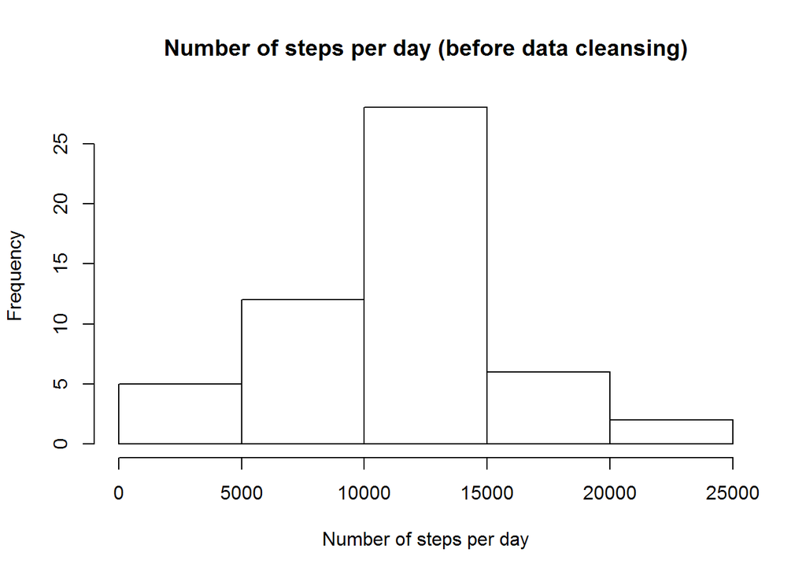

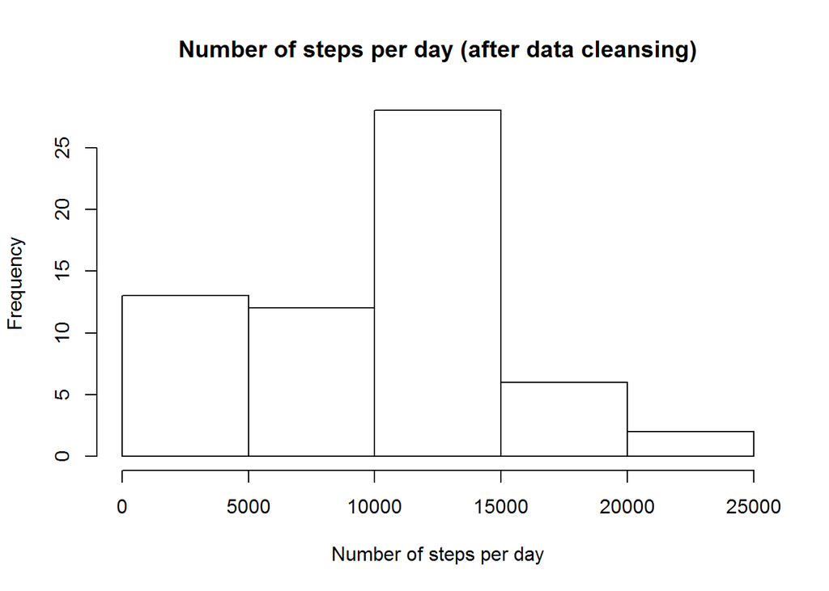

## Analysis

We can see from our data that our subject walked a mean 10766 steps and a median 10765 steps per day.

Let’s see what the number of steps taken looks like over time…

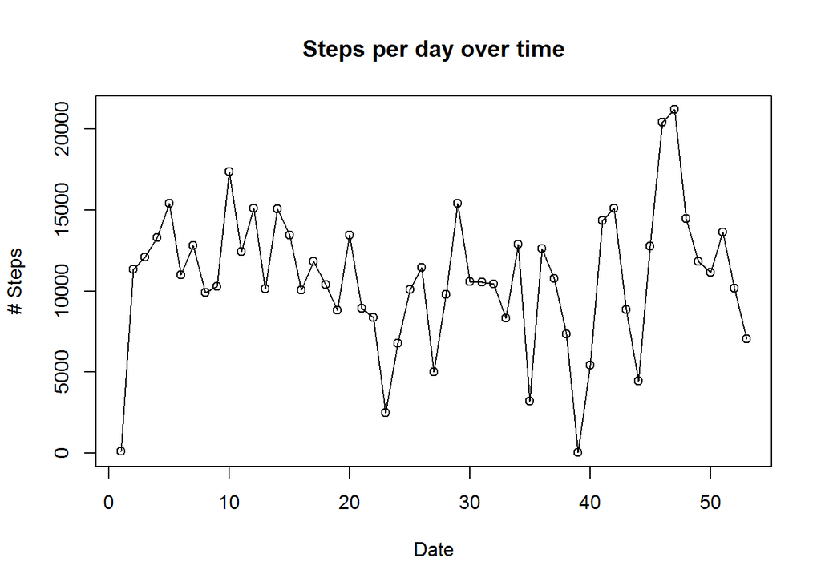

We can see that there is a fair amount of variability in the steps walked per day, with no immediately discernable pattern, and a couple of obvious days on which there was a very low amount of activity (often followed by a day of above average activity).

Next we want to see which particular 5-minute interval, on average, contains the maximum number of steps for the day.

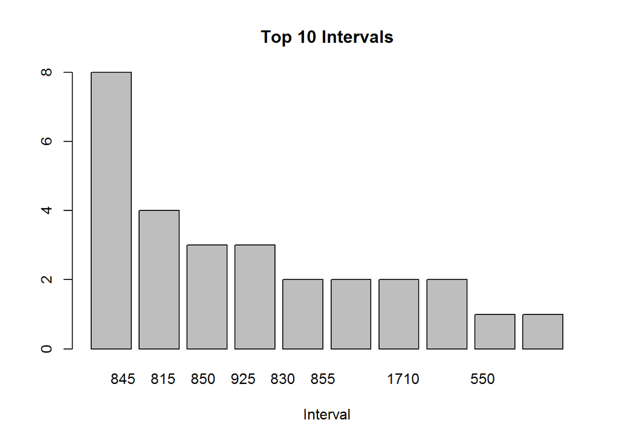

```r
# Firstly get the maximum value in any one interval per day
max.steps.pd <-
    aggregate(
        list(max.steps = df.cleaned$steps)
    ,   by=list(date = df.cleaned$date)
    ,   FUN=max
    )

# Next, find those numbered intervals which matched the maximum steps
joined.cases <- inner_join(max.steps.pd, df.cleaned, by="date")
matched.cases <- joined.cases %>% filter(steps==max.steps)

# Then we find which of the numbered intervals yields the greatest number of matches
matched.cases$count = 1
summed.cases <-
    aggregate(
        list(number.of.max.occurrences = matched.cases$count)
    ,   by=list(interval = matched.cases$interval)
    ,   FUN=sum)

no.vals.to.display <- 10

top.n.intervals <-
    head(
        arrange(
            summed.cases
        ,   desc(number.of.max.occurrences)
        )
    , no.vals.to.display)

top.n.intervals$ordinal.pos <- c(1:no.vals.to.display)

barplot(
    height=top.n.intervals$number.of.max.occurrences
,   xaxt="n", xlab="Interval"
,   main=paste(c("Top", no.vals.to.display, "Intervals"), collapse = " "))

axis(
    1
,   at=1:no.vals.to.display
,   labels=top.n.intervals$interval
,   tick=FALSE
)
```

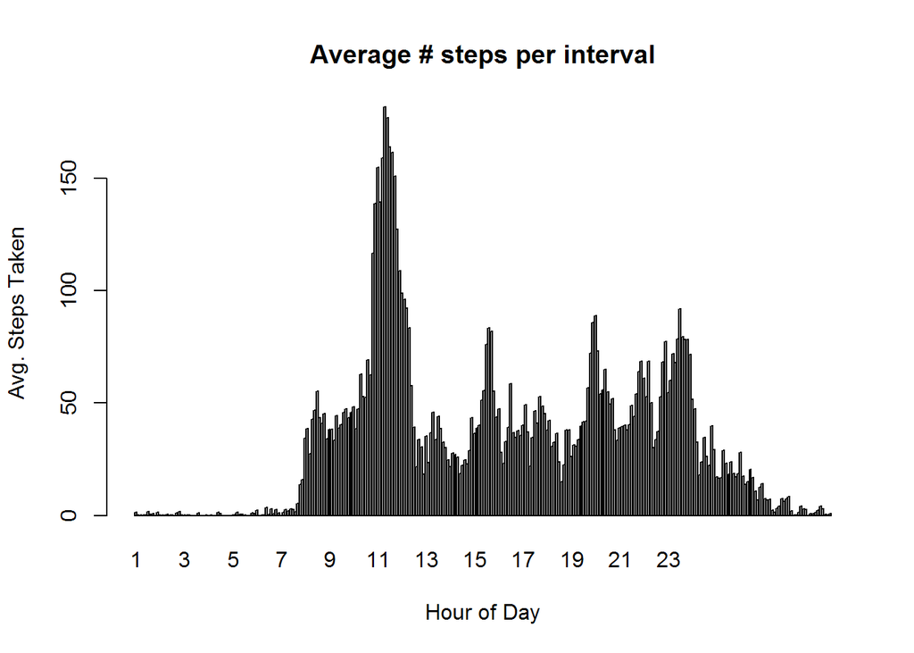

```r
# Draw a plot of the average number of steps per day, per interval
spi <-
    setNames(
        aggregate(
            df.cleaned$steps
        ,   by=list(df.cleaned$interval)
        ,   FUN=mean)
    ,   c("interval", "steps")
    )

spi <- arrange(spi, interval) # ensure that the intervals are in order

barplot(
    height=spi$steps
,   xaxt="n", xlab="Hour of Day", ylab="Avg. Steps Taken"
,   main="Average # steps per interval"
)

axis(
    1
    ,   at=seq(1, 288, 12)
    ,   labels=seq(1, 24, 1)
    ,   tick=FALSE
)
```

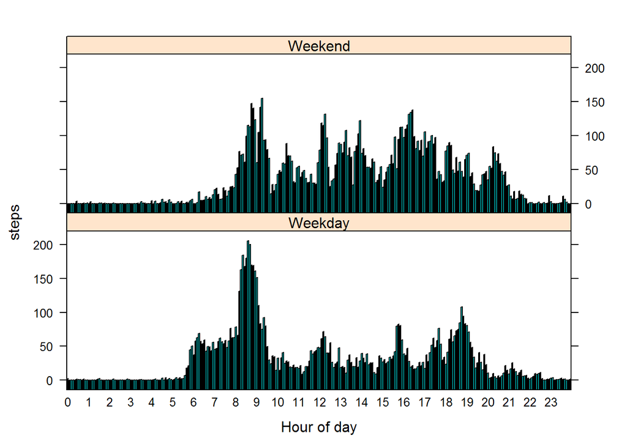

```r
# Work out which days are weekends and which are weekdays
df.cleaned$day.of.week <- weekdays(as.Date(df.cleaned$date))
df.cleaned$weekday.weekend[
    df.cleaned$day.of.week == "Saturday"
|   df.cleaned$day.of.week == "Sunday"
] <- "Weekend"
df.cleaned$weekday.weekend[is.na(df.cleaned$weekday.weekend)] <- "Weekday"

# Aggregate the average number of steps taken per interval, per weekday/weekend
# split
spi <-
    setNames(
        aggregate(
            df.cleaned$steps
        ,   by=list(
                df.cleaned$interval
            ,   df.cleaned$weekday.weekend
            )
        ,   FUN=mean)
    ,   c("interval", "weekday.weekend", "steps")
    )

# Draw a plot of the average number of steps per day, per interval, per
# weekday/weekend split
barchart(
    steps ~ interval | factor(weekday.weekend)
,   data=spi
,   horizontal=FALSE, layout=c(1,2)
,   scales=list(
        x=list(
            at=seq(1,288,12)
        ,   labels=seq(0,23,1)
        )
    )
, xlab="Hour of day"
)
```

Here we can see some clear differences in behaviour between weekends and weekdays:

- Weekend activity is more spread out throughout the day, whereas weekday activity is clustered around commuting times and lunchtime.
- Weekend activity continues until much later in the evening than weekday activity.
- On the whole, the subject is more active on weekends than during the weekday.